# Unsupervised Clustering of Wine Based on Chemical Analysis

Dibakar Bhowal

2025-03-31

## Loading Necessary Libraries

```r
library(factoextra)
library(tidyr)
library(caret)
library(e1071)
library(dplyr)
library(cluster)
library(tinytex)
library(dbscan)
library(fpc)
```

## Loading and Preparing the Data

```r
wines <- read.csv("/home/mukta/Downloads/Wine_Clustering.csv")
wines.norm <- scale(wines)  # Normalization of data for clustering
```

## Q1-A: Effect of Normalization and Number of Clusters (k)

**Normalization**: K-means relies on Euclidean distance, which is sensitive to scale. Normalization ensures that attributes with large values do not dominate clustering results.

**Choosing k**: The number of clusters affects the quality of clustering. We will use the **Elbow Method** and **Silhouette Analysis** to determine the optimal k.

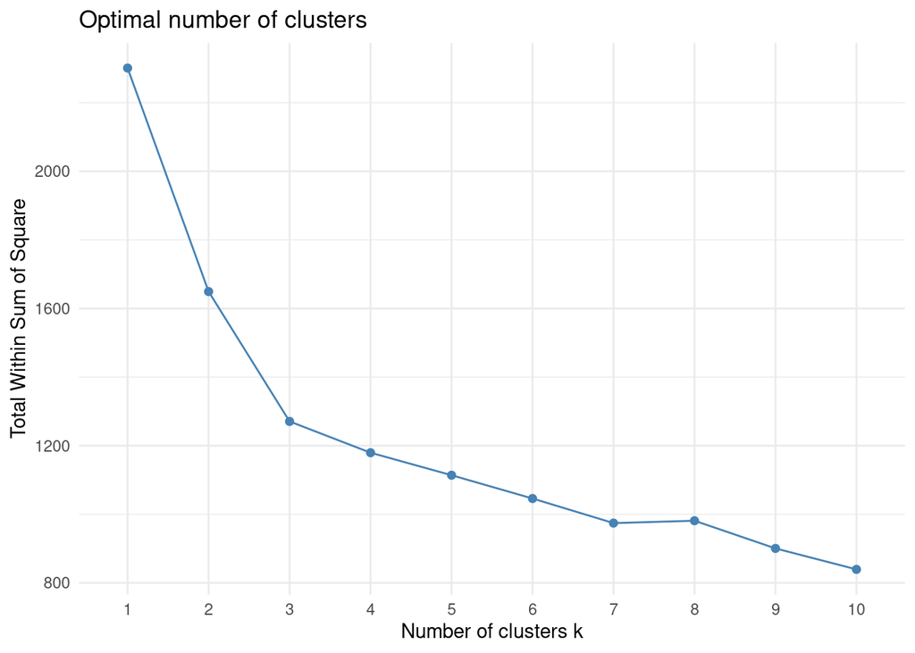

```r
# Find optimal k using WSS (Elbow Method)
fviz_nbclust(wines.norm, kmeans, method = "wss") + theme_minimal()
```

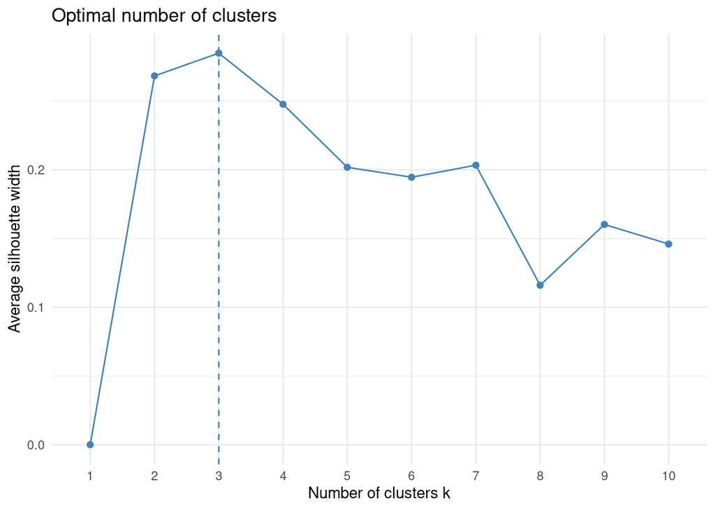

```r
# Find optimal k using Silhouette Method
fviz_nbclust(wines.norm, kmeans, method = "silhouette") + theme_minimal()
```

# Both methods indicate ‘3’ to be the optimal ‘k’ value.

## Q1-B: K-Means Clustering

# Applying K-Means clustering using ‘3’ as the optimal ‘k’ value.

```r
set.seed(123)
optimal_k <- 3  #
kmeans.wines <- kmeans(wines.norm, centers = optimal_k, nstart = 25)

# Print cluster centers and sizes
kmeans.wines$centers
```

```
##      Alcohol Malic_Acid        Ash Ash_Alcanity   Magnesium Total_Phenols
## 1  0.1644436  0.8690954  0.1863726    0.5228924 -0.07526047   -0.97657548
## 2  0.8328826 -0.3029551  0.3636801   -0.6084749  0.57596208    0.88274724
## 3 -0.9234669 -0.3929331 -0.4931257    0.1701220 -0.49032869   -0.07576891
##    Flavanoids Nonflavanoid_Phenols Proanthocyanins Color_Intensity        Hue
## 1 -1.21182921           0.72402116     -0.77751312       0.9388902 -1.1615122
## 2  0.97506900          -0.56050853      0.57865427       0.1705823  0.4726504
## 3  0.02075402          -0.03343924      0.05810161      -0.8993770  0.4605046
##        OD280    Proline
## 1 -1.2887761 -0.4059428
## 2  0.7770551  1.1220202
## 3  0.2700025 -0.7517257
```

```r
kmeans.wines$size
```

```
## [1] 51 62 65
```

```r
kmeans.wines$withinss
```

```
## [1] 326.3537 385.6983 558.6971
```

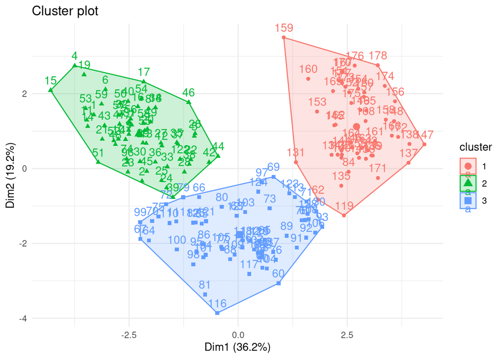

```r
# Visualize clusters
fviz_cluster(list(data = wines.norm, cluster = kmeans.wines$cluster)) + theme_minimal()
```

## Interpretation of K-Means Clusters

#Cluster 1: Represents wines with higher tartness and richness (e.g., higher Malic_Acid and Color_Intensity) but fewer antioxidant properties(e.g. lower Flavanoids and OD280).

#Cluster 2: Groups antioxidant-rich wines with higher Alcohol and Flavanoids, indicating a strong and bold flavor profile.

## Q2-A: DBSCAN vs K-Means

**Differences:** - **K-Means** assumes spherical clusters, requires ‘k’, and is sensitive to outliers. - **DBSCAN** detects arbitrarily shaped clusters, identifies outliers as noise, and does not require ‘k’.

## Q2-B: DBSCAN Clustering

# First, let’s determine an appropriate epsilon (ε) value using a k-distance plot. According to the instructions we have to assume k = 3 for this purpose. We will use PCA to reduce components for better results.

```r
pca <- prcomp(wines.norm, center = TRUE, scale. = TRUE)
wines.pca <- data.frame(pca$x[, 1:3])  # Selecting first 3 principal components
```

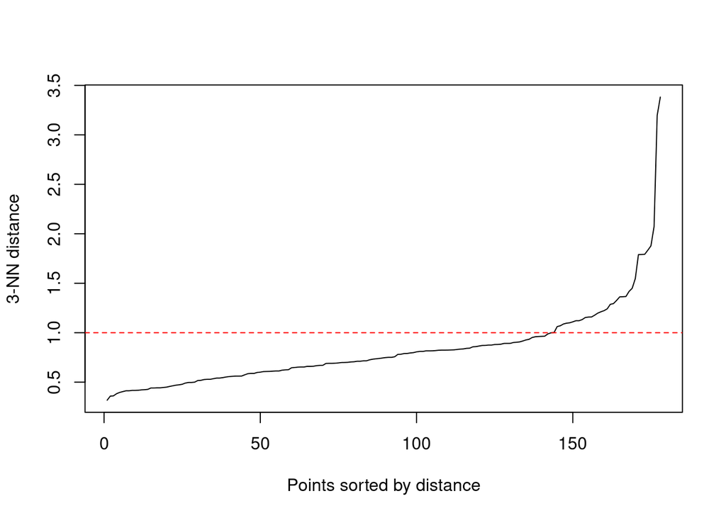

```r
# Finding epsilon using kNN distance plot
dbscan::kNNdistplot(wines.pca, k = 3)
abline(h = 1, col = "red", lty = 2)
```

# We can see around 1 ish the graph sharply ascends. Indicating Epsilon value might be ~1, We will try small deviations and pick whichever gives more consistent output.

# Applying DBSCAN clustering:

```r
DBscan.wines.pca <- fpc::dbscan(wines.pca, eps = 1, MinPts = 5)

# View results
print(DBscan.wines.pca)
```

```
## dbscan Pts=178 MinPts=5 eps=1
##         0   1  2
## border 24  20  5
## seed    0  90 39
## total  24 110 44
```

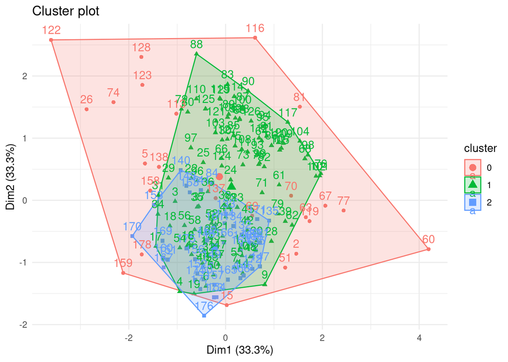

```r
# Visualize clusters
fviz_cluster(list(data = wines.pca, cluster = DBscan.wines.pca$cluster)) + theme_minimal()
```

## Interpretation of DBSCAN Clusters:

# Cluster 1: The largest cluster, with 110 points (90 core and 20 border points). This represents the majority group of wine samples with similar principal component patterns.

# Cluster 2: A smaller but distinct cluster with 44 points (39 core and 5 border points), likely representing a subgroup of wines with unique characteristics.

# Noise (Cluster 0): Contains 24 points classified as noise, indicating outliers that do not belong to any dense cluster.

### Influence of ε and minPts

- **ε (epsilon)**: Defines the radius of a neighborhood. A small ε leads to many small clusters or noise points, while a large ε may merge distinct clusters.
- **minPts**: Minimum points required to form a dense cluster. A higher value reduces noise but may miss smaller clusters.

# Q3: Comparison of K-Means and DBSCAN

| Feature | K-Means | DBSCAN |
| --- | --- | --- |
| Requires k? | Yes | No |
| Handles Outliers? | No | Yes |
| Works for Arbitrary Shapes? | No | Yes |
| Cluster Density Sensitivity | No | Yes |

### Conclusion

- K-Means is efficient for well-separated, spherical clusters.
- DBSCAN is useful for detecting noise and irregularly shaped clusters.
- The choice depends on dataset characteristics and clustering goals.